# Praca Domowa 2

Wojciech Grabias

2022-10-31

# Poprawa wykresu znalezionego w prasie na przestrzeni ostatnich 2 tygodni

# Cel pracy

Celem poniższej pracy jest przeanalizowanie wykresu przedstawiającego liczbę transportów cargo dla każdego kraju będącego końcowym odbiorcą przenoszonego ładunku. Dane odnoszą się jedynie do Morza Czarnego (końcowym odbiorcą może być jednak dowolne państwo).

Wykres pochodzi z oficjalnej strony Narodów Zjednoczonych: https://www.un.org/en/black-sea-grain-initiative/vessel-movements. Warto zauważyć, że strona jest aktualizowana na porządku dziennym, stąd analizowany może marginalnie różnić się od obecnie widniącego na stronie.

# Wykres niepoprawny

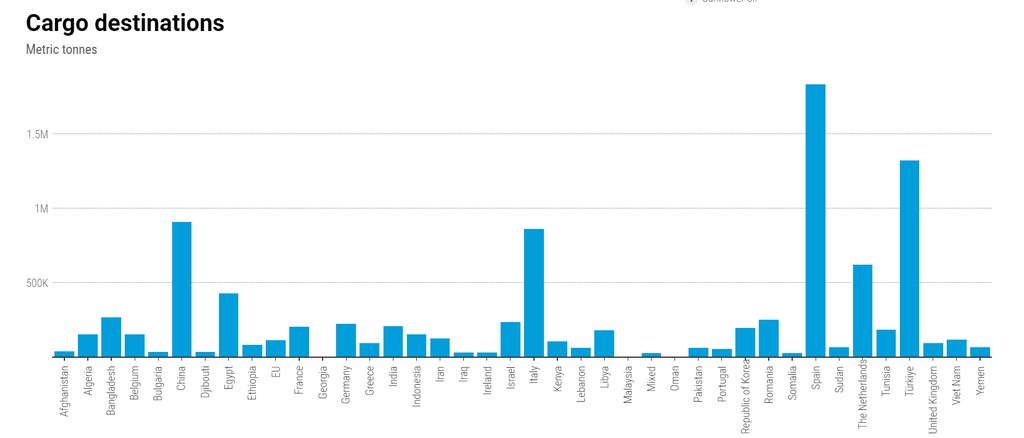

Wykres z oficjalnej strony United Nations na dzień 30.10.2022

Źródło wykresu: https://www.un.org/en/black-sea-grain-initiative/vessel-movements

# Wykres poprawiony

[figure not shown]

# Kod poprawionego wykresu

```r
setwd("C:/Users/wojte/OneDrive/Pulpit/twd2/")
df <- read.csv('Twd2_data.csv')

library(dplyr)
library(forcats)
library(ggplot2)

graph <- function(df){
  df %>%
    group_by(Country) %>%
    summarise(Tonnage = sum(Tonnage)/1000) %>%
    mutate(Country = fct_reorder(Country, Tonnage)) -> aggr

  aggr %>%
    ggplot(aes(x=Country, y=Tonnage)) +
    coord_flip() +
    expand_limits(y=0) +
    labs(title = "Cargo Destinations throughout The Black Sea",
         subtitle = "Data from 03.08.2022-29.10.2022",
         y = "Tonnage (1000s of metric tonnes)") +
    scale_y_continuous(expand = c(0,0)) +
    theme_bw(base_size = 15) +
    theme(axis.text.x = element_text(size = 15),
          axis.text.y = element_text(size = 13)) +
    geom_col(fill="lightblue", color="black", width= 0.87) ->res
  return(res)
}
```

# Uzasadnienie

Podstawową wadą wykresu oryginalnego jest to, że dane uporządkowane są alfabetycznie, co w dużym stopniu utrudnia odczytywanie danych ze względu na zakres przedstawianych wartości. Poprawiony wykres prezentuje dane w sposób uporządkowany, nie tylko podkreślając ekstrema, ale również ułatwiając odczytywanie danych.  
Ponadto, oś X wykresu niepoprawnego wykresu określona jest poprzez kraje zapisane prostopadle do osi, co w sposób znaczący uniemożliwia sprawny odczyt danych. W poprawionym wykresie, problem ten został rozwiązany poprzez odwrócenie osi - w ten sposób oba zakresy danych obrócone są poprawnie.  
Kolejną zaletą poprawionego wykresu nad błędnym jest to, że wszystkie dane są w pełni odczytywalne - na wykresie pierwszym kraje takie jak Oman czy Gruzja zaprezentowane są w sposób, jak gdyby miały zerową wartość otrzymywanych ładunków. W rzeczywistości jest to nieprawda, co widoczne jest na poprawionym wykresie - o ile jest to niewielka wartość, jest różna od zerowej.